# HW 3

This assignment covers several aspects of Linear Regresstion. **DO NOT ERASE MARKDOWN CELLS AND INSTRUCTIONS IN YOUR HW submission**

- **Q** - QUESTION
- **A** - Where to input your answer

## Instructions

Keep the following in mind for all notebooks you develop:

- Structure your notebook.
- Use headings with meaningful levels in Markdown cells, and explain the questions each piece of code is to answer or the reason it is there.
- Make sure your notebook can always be rerun from top to bottom (Kernel Tab -> Restart and Run All)
- Start working on this assignment as soon as possible. If you are a beginner in Python this might take a long time. One of the objectives of this assignment is to help you learn python and scikit-learn package.
- Follow README.md for homework submission instructions
- In this notebook we assume '../data/' location of all data files to be read and written

## Related sklearn material and online tutorials

[sklearn User Guide](https://scikit-learn.org/stable/user_guide.html)

### sklearn data pre-processing

- [train_test_split](https://scikit-learn.org/stable/modules/generated/sklearn.model_selection.train_test_split.html)
- [common_pittfalls](https://scikit-learn.org/stable/common_pitfalls.html)
- [train test split tutorial](https://towardsdatascience.com/train-test-split-and-cross-validation-in-python-80b61beca4b6)

### sklearn multiple linear regression

- [tutorial](https://scikit-learn.org/stable/modules/linear_model.html)
- [API documentation](https://scikit-learn.org/stable/modules/classes.html#module-sklearn.linear_model)
- [Linear Regression](https://scikit-learn.org/stable/modules/generated/sklearn.linear_model.LinearRegression.html#sklearn.linear_model.LinearRegression)
- [multiple linear regression tutorial](https://datagy.io/python-sklearn-linear-regression/)

### sklearn polynomial regression

- [generate polynomial features](https://scikit-learn.org/stable/modules/generated/sklearn.preprocessing.PolynomialFeatures.html)
- [polinomial regression tutorial](https://towardsdatascience.com/polynomial-regression-with-scikit-learn-what-you-should-know-bed9d3296f2)

### correlation

- [correlation](https://scikit-learn.org/stable/modules/generated/sklearn.feature_selection.r_regression.html)

# Linear Regression

In jupyter notebook environment, commands starting with the symbol % are magic commands or magic functions. `%%timeit` is one of such function. It basically gives you the speed of execution of certain statement or blocks of codes.

```python
import pandas as pd
import numpy as np
import seaborn as sns
import matplotlib.pyplot as plt
```

**Q1** Read the `car_data.csv` data (we assume ../data/ location of all data files to be read and written) from **data** folder using pandas. Replace the ??? in the code cell below to accomplish this taks.

**A1** Replace ??? with code in the code cell below

```python
# Replace ??? with code in the code cell below

df = pd.read_csv('data/Car_data.csv')
```

```python
# View head of the data to confirm the correctness of your answer
df.head()
```

|  | car_ID | symboling | CarName | fueltype | aspiration | doornumber | carbody | drivewheel | enginelocation | wheelbase | ... | enginesize | fuelsystem | boreratio | stroke | compressionratio | horsepower | peakrpm | citympg | highwaympg | price |
| --- | --- | --- | --- | --- | --- | --- | --- | --- | --- | --- | --- | --- | --- | --- | --- | --- | --- | --- | --- | --- | --- |
| 0 | 1 | 3 | alfa-romero giulia | gas | std | two | convertible | rwd | front | 88.6 | ... | 130 | mpfi | 3.47 | 2.68 | 9.0 | 111 | 5000 | 21 | 27 | 13495.0 |
| 1 | 2 | 3 | alfa-romero stelvio | gas | std | two | convertible | rwd | front | 88.6 | ... | 130 | mpfi | 3.47 | 2.68 | 9.0 | 111 | 5000 | 21 | 27 | 16500.0 |
| 2 | 3 | 1 | alfa-romero Quadrifoglio | gas | std | two | hatchback | rwd | front | 94.5 | ... | 152 | mpfi | 2.68 | 3.47 | 9.0 | 154 | 5000 | 19 | 26 | 16500.0 |
| 3 | 4 | 2 | audi 100 ls | gas | std | four | sedan | fwd | front | 99.8 | ... | 109 | mpfi | 3.19 | 3.40 | 10.0 | 102 | 5500 | 24 | 30 | 13950.0 |
| 4 | 5 | 2 | audi 100ls | gas | std | four | sedan | 4wd | front | 99.4 | ... | 136 | mpfi | 3.19 | 3.40 | 8.0 | 115 | 5500 | 18 | 22 | 17450.0 |

5 rows × 26 columns

## Data cleaning and manipulation

**Q2** Here, you will practice the usage of common data cleaning and manipulation functions in 3 steps.

1. Use isnull() to figure out the number of NaN values per column
2. Remove the column with majority NaN values (if any)
3. Check if there are still NaN values in the dataframe using `isna()` method

**A2** Replace ??? with code in the code cell below

```python
# There is no missing data here on this dataset :
#df.?
#df.?
df.isnull().sum() # prints out each column individually with an integer. If the integer > 0, then there are empty values
# it will be noticed that there are no null values in this dataset
```

```
car_ID              0
symboling           0
CarName             0
fueltype            0
aspiration          0
doornumber          0
carbody             0
drivewheel          0
enginelocation      0
wheelbase           0
carlength           0
carwidth            0
carheight           0
curbweight          0
enginetype          0
cylindernumber      0
enginesize          0
fuelsystem          0
boreratio           0
stroke              0
compressionratio    0
horsepower          0
peakrpm             0
citympg             0
highwaympg          0
price               0
dtype: int64
```

```python
# lets get some statistical information :
# df.?
df.describe()
```

|  | car_ID | symboling | wheelbase | carlength | carwidth | carheight | curbweight | enginesize | boreratio | stroke | compressionratio | horsepower | peakrpm | citympg | highwaympg | price |
| --- | --- | --- | --- | --- | --- | --- | --- | --- | --- | --- | --- | --- | --- | --- | --- | --- |
| count | 205.000000 | 205.000000 | 205.000000 | 205.000000 | 205.000000 | 205.000000 | 205.000000 | 205.000000 | 205.000000 | 205.000000 | 205.000000 | 205.000000 | 205.000000 | 205.000000 | 205.000000 | 205.000000 |
| mean | 103.000000 | 0.834146 | 98.756585 | 174.049268 | 65.907805 | 53.724878 | 2555.565854 | 126.907317 | 3.329756 | 3.255415 | 10.142537 | 104.117073 | 5125.121951 | 25.219512 | 30.751220 | 13276.710571 |
| std | 59.322565 | 1.245307 | 6.021776 | 12.337289 | 2.145204 | 2.443522 | 520.680204 | 41.642693 | 0.270844 | 0.313597 | 3.972040 | 39.544167 | 476.985643 | 6.542142 | 6.886443 | 7988.852332 |
| min | 1.000000 | -2.000000 | 86.600000 | 141.100000 | 60.300000 | 47.800000 | 1488.000000 | 61.000000 | 2.540000 | 2.070000 | 7.000000 | 48.000000 | 4150.000000 | 13.000000 | 16.000000 | 5118.000000 |
| 25% | 52.000000 | 0.000000 | 94.500000 | 166.300000 | 64.100000 | 52.000000 | 2145.000000 | 97.000000 | 3.150000 | 3.110000 | 8.600000 | 70.000000 | 4800.000000 | 19.000000 | 25.000000 | 7788.000000 |
| 50% | 103.000000 | 1.000000 | 97.000000 | 173.200000 | 65.500000 | 54.100000 | 2414.000000 | 120.000000 | 3.310000 | 3.290000 | 9.000000 | 95.000000 | 5200.000000 | 24.000000 | 30.000000 | 10295.000000 |
| 75% | 154.000000 | 2.000000 | 102.400000 | 183.100000 | 66.900000 | 55.500000 | 2935.000000 | 141.000000 | 3.580000 | 3.410000 | 9.400000 | 116.000000 | 5500.000000 | 30.000000 | 34.000000 | 16503.000000 |
| max | 205.000000 | 3.000000 | 120.900000 | 208.100000 | 72.300000 | 59.800000 | 4066.000000 | 326.000000 | 3.940000 | 4.170000 | 23.000000 | 288.000000 | 6600.000000 | 49.000000 | 54.000000 | 45400.000000 |

**Q3:** In this task, out of all categorical columns, we focus only on the `fueltype` column processing in 2 steps.

1. Use label encoder from sklearn and convert the `fueltype` categorical values to numerical values.
2. Create a new dataframe that contains only the numerical columns.

**A3** Replace ??? with code in the code cell below.

```python
# Label Encoding for 2-class columns:
from sklearn.preprocessing import LabelEncoder
# le = ?
# df.?
le = LabelEncoder()
unique_labels = [*df['fueltype'].unique()]
le.fit(unique_labels)
df['fueltype'] = le.transform(df['fueltype']) # didn't necessarily create a new dataframe, but was still able to transform all categorical values to numerical values
```

```python
# Create new dataframe with selected columns
#df=?
```

```python
df.head()
```

|  | car_ID | symboling | CarName | fueltype | aspiration | doornumber | carbody | drivewheel | enginelocation | wheelbase | ... | enginesize | fuelsystem | boreratio | stroke | compressionratio | horsepower | peakrpm | citympg | highwaympg | price |
| --- | --- | --- | --- | --- | --- | --- | --- | --- | --- | --- | --- | --- | --- | --- | --- | --- | --- | --- | --- | --- | --- |
| 0 | 1 | 3 | alfa-romero giulia | 1 | std | two | convertible | rwd | front | 88.6 | ... | 130 | mpfi | 3.47 | 2.68 | 9.0 | 111 | 5000 | 21 | 27 | 13495.0 |
| 1 | 2 | 3 | alfa-romero stelvio | 1 | std | two | convertible | rwd | front | 88.6 | ... | 130 | mpfi | 3.47 | 2.68 | 9.0 | 111 | 5000 | 21 | 27 | 16500.0 |
| 2 | 3 | 1 | alfa-romero Quadrifoglio | 1 | std | two | hatchback | rwd | front | 94.5 | ... | 152 | mpfi | 2.68 | 3.47 | 9.0 | 154 | 5000 | 19 | 26 | 16500.0 |
| 3 | 4 | 2 | audi 100 ls | 1 | std | four | sedan | fwd | front | 99.8 | ... | 109 | mpfi | 3.19 | 3.40 | 10.0 | 102 | 5500 | 24 | 30 | 13950.0 |
| 4 | 5 | 2 | audi 100ls | 1 | std | four | sedan | 4wd | front | 99.4 | ... | 136 | mpfi | 3.19 | 3.40 | 8.0 | 115 | 5500 | 18 | 22 | 17450.0 |

5 rows × 26 columns

**Q4:** Use seaborn histplot to plot a distribution graph for the engine sizes

**A4** Replace ??? with code in the code cell below

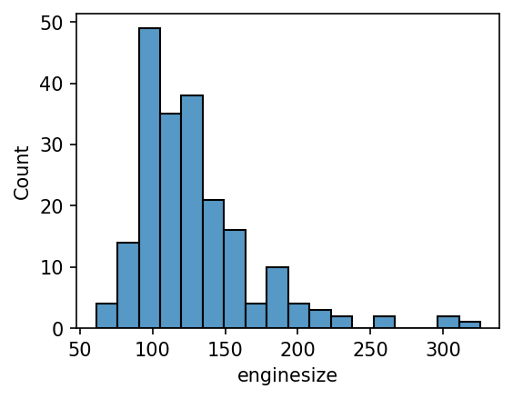

```python
plt.figure(figsize=(4,3),dpi=150)
sns.histplot(data=df['enginesize'])
```

**Q5:** Use seaborn histplot to plot a distribution graph for the car prices

**A5** Replace ??? with code in the code cell below

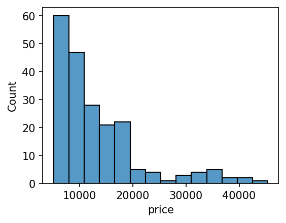

```python
plt.figure(figsize=(4,3),dpi=150)
sns.histplot(data=df['price'])
```

**Q6:** Use seaborn scatterplot to present the relation between enginesize and the horsepower of a car

**A6** Replace ??? with code in the code cell below

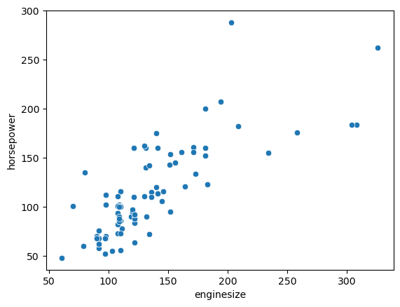

```python
#sns.?
sns.scatterplot(x=df['enginesize'], y=df['horsepower'])
```

Next, use `hue` parameter of scatterplot function to illustrate datapoints that relate to specific fueltype category.

**A7** Replace ??? with code in the code cell below

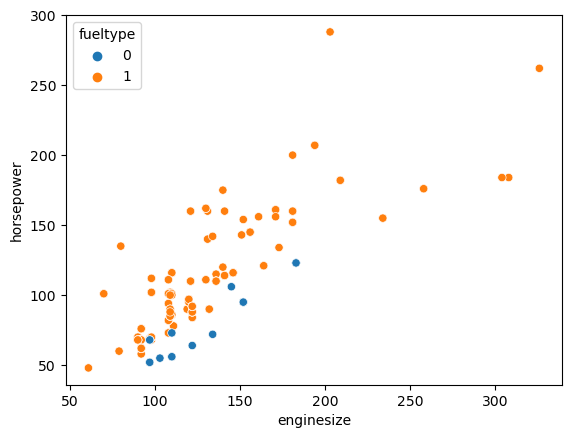

```python
#sns.?
sns.scatterplot(data=df, x=df['enginesize'], y=df['horsepower'], hue='fueltype')
```

**Q8:** Use pairplot from sns to plot the data frame `df` and justify your feature selection.

**A8:** replace ??? with code in the code cell below.

[output not shown]

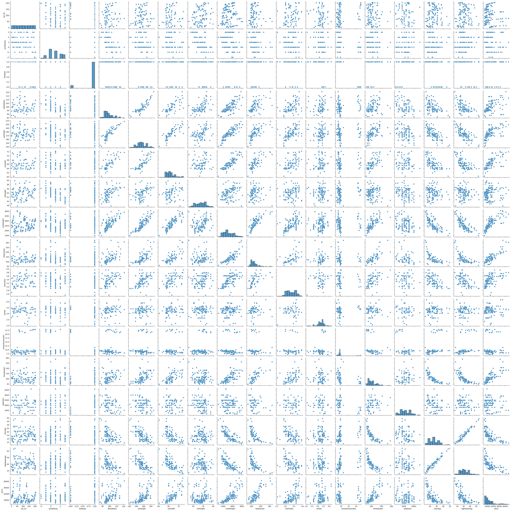

```python
# 2. Use pairplot from sns to plot our data frame df
#sns.?
sns.pairplot(data=df)
```

**Q9** Data Visualization:

1. Use heatmap chart from seaborn library to findout the correlation between the columns in our dataset.
2. Update data frame 'df' to contain 5 columns from existing 'df' with the highest correlation to column "price". Also include price column in the updated data frame.

**A9** Replace ??? with code in the code cell below

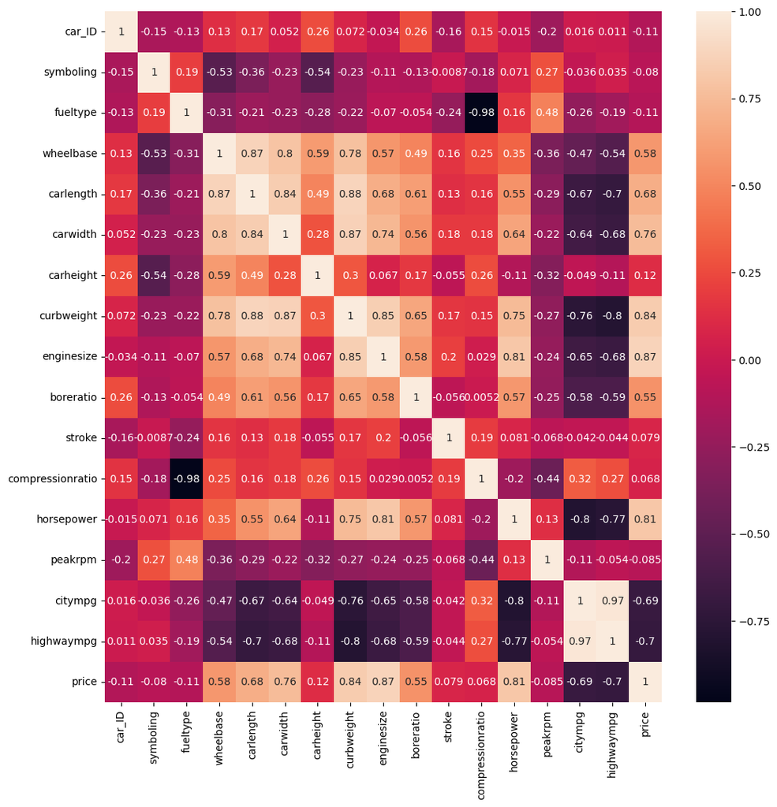

```python
#corr_matrix = df.corr()
#plt.figure(figsize=(12,12))
#sns.?

df.head() # CarName, aspiration, doornumber, carbody, drivewheel, enginelocation, fuelsystem
corr_matrix = df.drop(columns=['CarName', 'aspiration', 'doornumber', 'carbody', 'drivewheel', 'enginelocation', 'enginetype', 'cylindernumber', 'fuelsystem']).corr()
plt.figure(figsize=(12,12))
sns.heatmap(corr_matrix, annot=True)
```

```python
# Task 2: Update data frame 'df' to contain 5 columns from existing 'df' with the highest correlation to column "price" and the price column itself.
# is this 5 columns + the price column? enginesize = 87, curbweight = 84, horsepower = 81, carwidth = 76, highwaympg = -70
#df=?
df = df[['price', 'enginesize', 'curbweight', 'horsepower', 'carwidth', 'highwaympg']]
df.head()
```

|  | price | enginesize | curbweight | horsepower | carwidth | highwaympg |
| --- | --- | --- | --- | --- | --- | --- |
| 0 | 13495.0 | 130 | 2548 | 111 | 64.1 | 27 |
| 1 | 16500.0 | 130 | 2548 | 111 | 64.1 | 27 |
| 2 | 16500.0 | 152 | 2823 | 154 | 65.5 | 26 |
| 3 | 13950.0 | 109 | 2337 | 102 | 66.2 | 30 |
| 4 | 17450.0 | 136 | 2824 | 115 | 66.4 | 22 |

## Data Preparation

**Q10** Pre-processing

1. Assign 'price' column value to y and rest of the columns to x

**A10** Replace ??? with code in the code cell below

```python
#y =?
#X =?
#X
y = df['price']
X = df.drop(columns=['price'])
```

**Q11** Use train_test_split to split the data set as train:test=(80%:20%) ratio.

**A11** Replace ??? with code in the code cell below

```python
from sklearn.model_selection import train_test_split

# X_train, X_test, y_train, y_test =?
# View the shape of your data set
# X_train.shape, X_test.shape, y_train.shape, y_test.shape
X_train, X_test, y_train, y_test = train_test_split(X, y, test_size=0.20, random_state=42)
X_train.shape, X_test.shape, y_train.shape, y_test.shape
```

```
((164, 5), (41, 5), (164,), (41,))
```

## Regression Task

### Multiple Linear Regression

**Q12** Fit multiple linear regression model on training data using all predictors, see (i) [Linear Regression Example](https://scikit-learn.org/stable/auto_examples/linear_model/plot_ols.html#sphx-glr-auto-examples-linear-model-plot-ols-py); (ii) [scikit-learn linear model](https://scikit-learn.org/stable/modules/linear_model.html)

$ Y = \beta_0 + \beta_1*x_1 + \beta_2*x_2 + ...\beta_p*x_p$

**A12:** Replace ??? with code in the code cell below

```python
from sklearn.linear_model import LinearRegression
#linear_model = ?
#linear_model.?
linear_model = LinearRegression()
linear_model.fit(X_train, y_train)
```

```
LinearRegression()
```

**Q13:** Model Scoring

1. Calculate the test MSE
2. Print the score from the model using test data

**A13** Replace ??? with code in the code cell below

```python
### Treadway Test, this does not answer A13.
### The MSE seemed so large, that I decided to prove to myself that the MSE was correct.
### I wrote my own MSE calculation within this cell, and it matches the MSE in the below cell.

# MSE = (1/n)sum(yi - yhat k )^2
# MSE = (1/n)sum(y actual - y predicted)^2
y_predict = linear_model.predict(X_test)
frame = pd.DataFrame({'y_test': y_test, 'y_predict': y_predict})
frame['difference'] = frame['y_test'] - frame['y_predict']
frame['square'] = frame['difference'] ** 2
#frame[:30]
frame.shape
mse_ = (1/frame.shape[0])*frame['square'].sum()
print(frame.head())
print(mse_)
# there's only 41 rows, but the differences between
```

```
        y_test     y_predict   difference        square
15   30760.000  25834.948104  4925.051896  2.425614e+07
9    17859.167  18803.324891  -944.157891  8.914341e+05
100   9549.000  11298.304551 -1749.304551  3.060066e+06
132  11850.000  13694.906024 -1844.906024  3.403678e+06
68   28248.000  23680.377070  4567.622930  2.086318e+07
14565923.040455319
```

```python
# Calculate the score on train and test sets
# Your code goes below
from sklearn.metrics import mean_squared_error
import matplotlib.pyplot as plt
#y_pred=?
#mse = ?   # Calculate the test MSE
#print("Test mean squared error (MSE): {:.2f}".format(mse))

y_pred = linear_model.predict(X_test)
mse = mean_squared_error(y_test, y_pred)
print("Test mean squared error (MSE): {:.2f}".format(mse))
print("Test Score: ", linear_model.score(X_test, y_test))
```

```
Test mean squared error (MSE): 14565923.04
Test Score:  0.8154904845465165
```

### Polinomial Regression

**Q14:** Polynomial extension of the feature set captures the non-linear dependencies in the data

1. Create a polinomial feature transformer with degree **TWO** using sklearn library [PolynomialFeatures](https://scikit-learn.org/stable/modules/generated/sklearn.preprocessing.PolynomialFeatures.html)
2. Transform the training dataset using the polinomial feature transformer

**A14** Replace ??? with code in the code cell below

```python
from sklearn.preprocessing import PolynomialFeatures
#poly =?
#poly_features = ?
poly = PolynomialFeatures(2)
poly_features = poly.fit_transform(X_train)
```

**Q15:** Train the new model

1. Create a LinearRegression model using sklearn
2. Train the model using the transformed Train data(X_train)/ or Polinomial train data
3. Print the score for the Polinomial Regression for the Train data.

See (i) [Linear Regression Example](https://scikit-learn.org/stable/auto_examples/linear_model/plot_ols.html#sphx-glr-auto-examples-linear-model-plot-ols-py); (ii) Use the transformed X_train features inside the score() function for the correct model scores.

**A15** Replace ??? with code in the code cell below

```python
#poly_reg_model = ?
#poly_reg_model.?

#poly_reg_model.?
poly_reg_model = LinearRegression()
poly_reg_model.fit(poly_features, y_train)
poly_reg_model.score(poly_features, y_train)
```

```
0.8887500925831316
```

```python
# May as well do the test set too
poly_features_test = poly.fit_transform(X_test)
poly_reg_model.score(poly_features_test, y_test)
```

```
0.7939905153296574
```